# R Bootcamp 1.5 Manipulating data in R

last update: 2021-08-08

## Data sumo

> Wrangling a big dataset is like sumo wresting -

> you have to use leverage

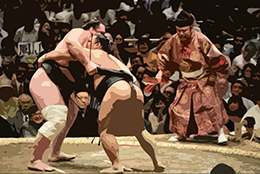

## What you will learn

- Indexing concept
- Using `which()` and subsetting
- Selection on `data.frame` objects
- Using `aggregate()`
- Practice exercises

## “Tidy Data” concept

## Indexing concept

**Vectors** of data are like houses on a street. Each house contains a data value and each house has an address.

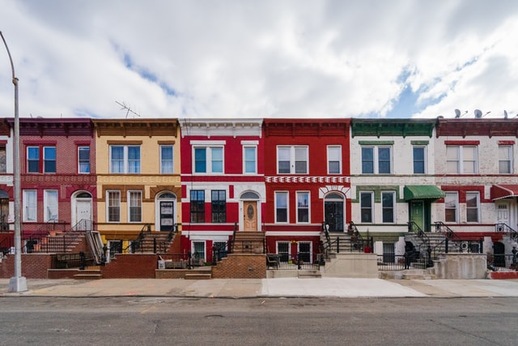

## Indexing concept

A **vector** of data has ‘addresses’ 1 to *i*

`my_vector[1:i]` indicates all the addresses in a vector

```r
my_vec <- c(1,7,3,5) # 4 addresses
length(my_vec)
```

```
## [1] 4
```

```r
my_vec[1:4]
```

```
## [1] 1 7 3 5
```

## Matrix indices

**Matrices** of data are like houses on multiple streets. Each house has an address and so does each “row” of houses.

[figure not shown]

## **Matrix** indices

A **matrix** of data has rows and columns.

Row “addresses” 1 to *i*, column addresses 1 to *j*. `my_vector[1:i, 1:j]` indicates all the addresses in a matrix.

```r
my_mat <- matrix(c(1,7,3,5), nrow = 2) # 2 rows
dim(my_mat)
```

```
## [1] 2 2
```

```r
my_mat[1:2, 1:2]
```

```
##      [,1] [,2]
## [1,]    1    3
## [2,]    7    5
```

## Array indices

**Arrays** of data are like skyscrapers (well, ones with 3 dimensions are…). Each array viewed from above has rows and columns of rooms, but also depth consisting of floors.

[figure not shown]

## Array indices

So, **arrays** have more than 2 dimensions.

A 3 dimensional array has row “addresses” 1 to *i*, column addresses 1 to *j*, and depth of 1 to *k*.

`my_arr[1:i, 1:j, 1:k]` indicates all the addresses in the array.

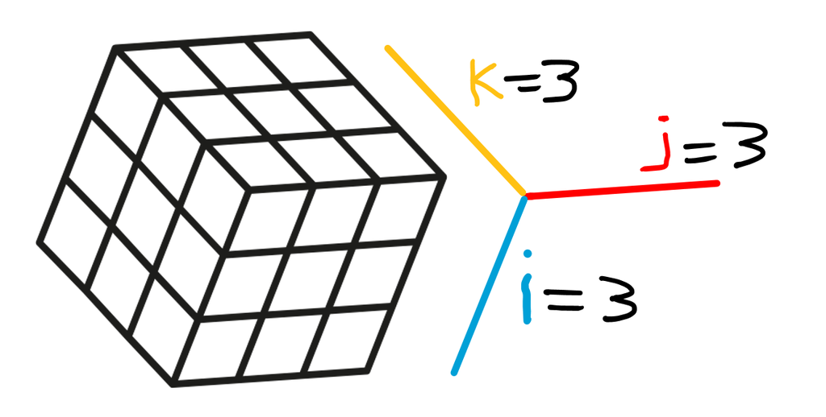

## Array indices

```r
my_arr <- array(c(1,7,3,5,
                  2,5,3,4,
                  3,6,7,8),
                dim = c(2,2,3)) # i,j,k
dim(my_arr)
```

```
## [1] 2 2 3
```

## Array indices `my_arr[1:2, 1:2, 1:3]`

```
## , , 1
##
##      [,1] [,2]
## [1,]    1    3
## [2,]    7    5
##
## , , 2
##
##      [,1] [,2]
## [1,]    2    3
## [2,]    5    4
##
## , , 3
##
##      [,1] [,2]
## [1,]    3    7
## [2,]    6    8
```

## `data.frame` indices

Data frames are like matrices, where the columns have names

```r
data("OrchardSprays")
head(OrchardSprays)
```

```
##   decrease rowpos colpos treatment
## 1       57      1      1         D
## 2       95      2      1         E
## 3        8      3      1         B
## 4       69      4      1         H
## 5       92      5      1         G
## 6       90      6      1         F
```

## `data.frame` indices

Access data with numerical indices

```r
# rows 1:6 of column 1
OrchardSprays[1:6, 1]
```

```
## [1] 57 95  8 69 92 90
```

```r
# by column name
OrchardSprays[1:6, "treatment"]
```

```
## [1] D E B H G F
## Levels: A B C D E F G H
```

## The `which()` function

`which()` returns addresses of data objects based on some conditional value

```r
OrchardSprays$treatment == "A"
```

```
##  [1] FALSE FALSE FALSE FALSE FALSE FALSE FALSE  TRUE FALSE FALSE FALSE FALSE
## [13] FALSE  TRUE FALSE FALSE FALSE FALSE  TRUE FALSE FALSE FALSE FALSE FALSE
## [25] FALSE  TRUE FALSE FALSE FALSE FALSE FALSE FALSE FALSE FALSE FALSE  TRUE
## [37] FALSE FALSE FALSE FALSE  TRUE FALSE FALSE FALSE FALSE FALSE FALSE FALSE
## [49] FALSE FALSE FALSE FALSE  TRUE FALSE FALSE FALSE FALSE FALSE FALSE FALSE
## [61] FALSE FALSE  TRUE FALSE
```

```r
which(OrchardSprays$treatment == "A")
```

```
## [1]  8 14 19 26 36 41 53 63
```

## Powerful Sumo with `which()`

```r
OrchardSprays$decrease
```

```
##  [1]  57  95   8  69  92  90  15   2  84   6 127  36  51   2  69  71  87  72   5
## [20]  39  22  16  72   4 130   4 114   9  20  24  10  51  43  28  60   5  17   7
## [39]  81  71  12  29  44  77   4  27  47  76   8  72  13  57   4  81  20  61  80
## [58] 114  39  14  86  55   3  19
```

```r
(my_selec <- which(OrchardSprays$treatment == "A"))
```

```
## [1]  8 14 19 26 36 41 53 63
```

```r
OrchardSprays$decrease[my_selec]
```

```
## [1]  2  2  5  4  5 12  4  3
```

## The `aggregate()` function

Summarizes a data object with FUN (a function you choose).

E.g. mean of variable for each factor level

```r
aggregate(x = OrchardSprays$decrease,
          by = list(OrchardSprays$treatment),
          FUN = mean)
```

```
##   Group.1      x
## 1       A  4.625
## 2       B  7.625
## 3       C 25.250
## 4       D 35.000
## 5       E 63.125
## 6       F 69.000
## 7       G 68.500
## 8       H 90.250
```

## Live coding

[figure not shown]